# Metric MDS: complete experiment

The installed benchmark bundle retains every attempted-fit summary, including failures, scores and timings, and the fixed seed-1 layouts shown here. Complete layouts and evaluation targets are retained in the source checkout under `tools/pkg/fixtures/documentation-data/` for independent recomputation. Static figures are used by default; set `options(grip.vignette.interactive = TRUE)` with ivue and rgl installed to render the interactive views.

## What is being compared?

`metric.mds()` fits Euclidean coordinates to graph shortest-path distances. Its default `backend = "sgd"` uses native stochastic gradient descent (SGD), based on [Zheng, Pawar and Goodman (2018)](https://doi.org/10.1109/TVCG.2018.2859997), with the default learning-rate schedule following [Hangan, Kobourov and Miller (2026)](https://arxiv.org/abs/2605.00641). SGD visits pairs of points in a randomly shuffled order, moving each pair closer together or farther apart to better match its target distance. These changes take effect immediately, and the learning-rate schedule reduces the size of the adjustments as fitting proceeds.

The alternative `backend = "smacof"` uses the optional **smacof** package ([Mair, Groenen and de Leeuw, 2022](https://doi.org/10.18637/jss.v102.i10)). SMACOF combines information from all pairs before updating the entire configuration at once. Each update is designed to reduce total stress; an individual SGD adjustment need not reduce total stress, even though it improves the distance for the pair being adjusted. With the default `pair.weights = "uniform"`, both minimize the same raw distance stress:

$$S(Z) = \sum_{i<j} \bigl(\lVert z_i-z_j\rVert-d_{ij}\bigr)^2.$$

Both also support `pair.weights = "inverse_squared"`, the graph-drawing weighting used by [Zheng, Pawar and Goodman (2018)](https://doi.org/10.1109/TVCG.2018.2859997). The weighting comparison below shows how this changes the fitted layouts. The original 420-fit comparison uses uniform weighting throughout.

This is a comparison of these implementations and settings on small synthetic examples. For a more extensive comparison of SGD and SMACOF across 18 benchmark datasets, see [Hangan, Kobourov and Miller (2026)](https://arxiv.org/abs/2605.00641), who compare their SGD solver with scikit-learn’s SMACOF implementation.

The figure labels and plots use **normalized error**, $\sqrt{S(Z)/\sum_{i<j}d_{ij}^2}$. Lower is better; zero means exact agreement with the target distances. Within a dataset, its ranking is identical to raw stress. Raw stress is also reported. We recompute both from the returned coordinates, rather than compare differently normalized backend reports.

The precomputed experiment uses 14 datasets, five paired starts, three allowances, and two backends: **420 planned fits**. Every example is displayed below, including both cloud sizes. Except for the planar control, all fits and interactive views are three-dimensional. The plane is fitted and plotted in two dimensions.

The main metric-MDS guide introduces the methods and highlights representative examples. This appendix preserves the full protocol, all sample sizes, outcomes, and saved comparisons.

## Datasets and timing protocol

The plane, paraboloid and saddle use regular 8-by-8 and 12-by-12 grids on $[-1,1]^2$, giving 64 and 144 vertices. Their lifts are, respectively, $z=0$, $z=0.8(x^2+y^2)$, and $z=0.8(x^2-y^2)$. The Gaussian clouds have three independent standard-normal coordinates with fixed seeds. The spatial graph follows a helix $(\cos t,\sin t,t/\pi)$, $0\leq t\leq3\pi$, with edges between consecutive vertices and between vertices seven indices apart. Every graph edge is weighted by its Euclidean length in the generating coordinates.

For the paraboloid and saddle, two target definitions are compared:

- **Ambient Euclidean:** all straight-line distances in the generating 3D cloud, represented by a complete weighted graph. An exact 3D realization exists; classical MDS provides a useful numerical check.
- **Local graph paths:** shortest paths on the grid with horizontal, vertical, and both diagonal connections. These are exact distances for that finite graph, **not exact geodesic distances on the continuous quadform**. They depend on sampling and allowed directions. Small graph-distance stress need not reconstruct the generating surface.

The helix uses local graph-path targets. Its generating coordinates are a reference drawing, not a guaranteed exact realization of all graph distances. The reference mesh on each quadform connects corresponding sampled vertices; it is a display aid, not a geodesic or surface-recovery certificate.

For every dataset, both backends receive the **same saved starting-coordinate recipe**, for seeds 1–5, and `n.init = 1`. Each allowance of 10, 30 or 100 starts a separate fit from those coordinates. SGD uses the hybrid schedule with initial rate 0.5, boundary rate 0.01, switch fraction 0.4, and scoring after every pass; SMACOF uses `eps = 1e-8`. Backend order alternates between paired blocks. No setting was chosen from the observed winners.

Elapsed fitting time includes the wrapper, target normalization, optimization, and checkpoint scoring. Shared graph preparation, process startup, namespace loading, independent final scoring, alignment, and rendering are excluded. The two namespaces are loaded before timing either backend. Each fit runs in an isolated process with a 30-second allowance; the full experiment has a 1,800-second allowance. Errors and timeouts remain in the result table and are not replaced by successful reruns. These are provisional workload limits.

The plots show median time and median normalized error across five starts, with horizontal and vertical interquartile ranges. Numeric labels identify the allowances. **Each marker is a separate restarted experiment, not a checkpoint on one optimization trajectory.** There is no retrospective best-of-three selection. Values below 0.001 seconds or error below $10^{-12}$ are clipped only for logarithmic plotting; the tables retain measured values.

```r
knitr::kable(as.data.frame(table(Backend = rows$backend, Status = rows$status)),
             col.names = c('Backend','Outcome','Fits'))
```

| Backend | Outcome | Fits |
| --- | --- | --- |
| sgd | ok | 210 |
| smacof | ok | 210 |

```r
knitr::kable(do.call(rbind, lapply(split(rows, rows$backend), function(z) {
  data.frame(Backend = z$backend[1], Fits = nrow(z),
    `Successful fits` = sum(z$status == 'ok'),
    `Total fit seconds` = sum(z$seconds, na.rm = TRUE),
    `Total worker seconds` = sum(z$worker_seconds), check.names = FALSE)
})), row.names = FALSE, digits = 3)
```

| Backend | Fits | Successful fits | Total fit seconds | Total worker seconds |
| --- | --- | --- | --- | --- |
| sgd | 210 | 210 | 7.441 | 273.481 |
| smacof | 210 | 210 | 5.173 | 268.876 |

At the largest allowance (100 passes/iterations), SGD has lower normalized error in **69 of 70 completed pairs**, and SMACOF in **1**; differences no larger than $10^{-10}$ count as ties. This compares a specified iteration allowance, not equal elapsed time. Across all three allowances, total recorded fitting time is **7.441 seconds for SGD** and **5.173 for SMACOF**. These examples favor SGD’s achieved accuracy but do not establish a universal speed advantage. Use the per-example plots to examine the trade-off.

An `ok` outcome means a fit returned usable coordinates; it does not mean convergence. Figure tables below report the actual pass/iteration count and termination reason. Worker time includes startup and communication and is reported separately. For a forcibly stopped worker, fitting time may be unavailable; summing recorded fitting time alone would then understate total effort. Timing is machine-dependent, especially for these small examples. This run used a shared workstation without CPU isolation; short timings are sensitive to background activity and timer resolution.

## How to read the embedding figures

**Gray is the generating reference; blue is SGD; orange is SMACOF.** Each saved experiment figure shows seed 1 and allowance 100, selected in advance and identically for both backends. It is not the best seed or the fit nearest the median. A failed selected run stays unavailable. Figure tables report that exact run’s error, raw stress and fitting time, as well as a separately computed classical-MDS reference.

Except for the two local-graph saddle examples described below, we center each fit, then apply an orthogonal rotation/reflection to match corresponding reference vertices. **No rescaling is performed for alignment.** The reported scores use original returned coordinates. These operations preserve all fitted distances; shared axes retain the input units. Blue and orange graph segments show the same edges in each embedding. Dense complete graphs are shown as clouds, avoiding thousands of overlapping edges.

The two **Saddle: Local graph paths** examples use surface-shape alignment. This display matches nearby surface locations without requiring their vertex labels to agree. It uses translation, rotation and reflection only: scale, fitted distances and stress stay unchanged. A closer surface overlay therefore does not mean that corresponding vertices or the original geometry were recovered.

In interactive rendering, each 3D figure has a layout selector below it. Choose SGD, SMACOF, or both; the gray generating reference stays visible. In the stress-weighting examples, choose one backend and weighting combination or all layouts. Changing the selection keeps the same camera, alignment and scale. Drag to rotate and scroll to zoom.

These interactive views require a current `ivue` and `rgl`; saved surface alignment is reused during rendering. The other examples provide saved images when interactive rendering is unavailable. The plane uses 2D panels. To recreate a surface-aligned view with just one configuration, set `show` to `"reference"`, `"sgd"`, or `"smacof"`:

```r
bundle <- readRDS(system.file('extdata', 'metric-mds-comparison',
                              'benchmark.rds', package = 'grip'))
case <- bundle$cases[['saddle_graph-144']]
fits <- comparison_representative(bundle, case$id)
surface <- comparison.surface.saved(case, fits)
comparison_view(case, fits, show = 'sgd', surface.alignments = surface$registrations)
comparison_view(case, fits, show = 'smacof', surface.alignments = surface$registrations)
comparison_view(case, fits, show = 'overlay', surface.alignments = surface$registrations)
```

`ivue` is optional and is available from [its source repository](https://github.com/pgajer/ivue). Its public `plot3D.groups()`, `layer3D.callback()`, `layer3D.axes()` and `camera.zup()` methods build these views. It does not fit or modify the embeddings. Set `options(grip.vignette.interactive = FALSE)` (the default) before rendering to use saved images where available, even when ivue is installed. Overlapping colors may hide very close fits; use the selector to inspect them separately.

## Gaussian cloud: Ambient Euclidean

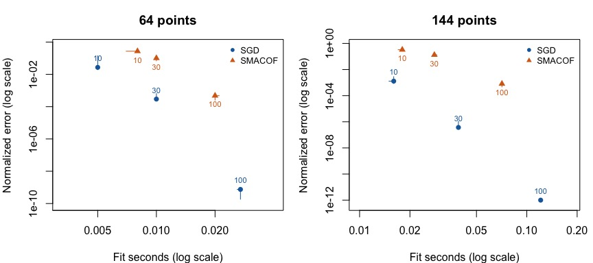

Separate schedules: median normalized error versus median fitting time; bars show the interquartile ranges over five starts. Labels are pass/iteration allowances.

### 64 points

| Method | Raw stress | Normalized error | Fit seconds | Passes/iterations | Termination |
| --- | --- | --- | --- | --- | --- |
| Generating reference | 3.056e-29 | 5.263e-17 | NA | NA | Reference only |
| Classical MDS | 2.474e-27 | 4.736e-16 | 0.002 | NA | Spectral reference |
| SGD | 1.843e-12 | 1.293e-08 | 0.027 | 100 | iteration_limit |
| SMACOF | 7.103e-04 | 2.537e-04 | 0.020 | 100 | iteration_limit |

Fixed seed 1, allowance 100. Gray: generating reference; blue: SGD; orange: SMACOF. The table above reports the exact displayed fits. Alignment preserves scale.

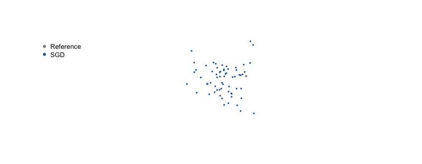

### 144 points

| Method | Raw stress | Normalized error | Fit seconds | Passes/iterations | Termination |
| --- | --- | --- | --- | --- | --- |
| Generating reference | 1.638e-28 | 5.176e-17 | NA | NA | Reference only |
| Classical MDS | 5.115e-26 | 9.146e-16 | 0.002 | NA | Spectral reference |
| SGD | 3.615e-26 | 7.689e-16 | 0.121 | 100 | iteration_limit |
| SMACOF | 7.153e-01 | 3.420e-03 | 0.071 | 100 | iteration_limit |

Fixed seed 1, allowance 100. Gray: generating reference; blue: SGD; orange: SMACOF. The table above reports the exact displayed fits. Alignment preserves scale.

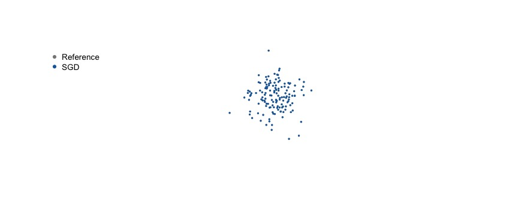

## Plane: Ambient Euclidean

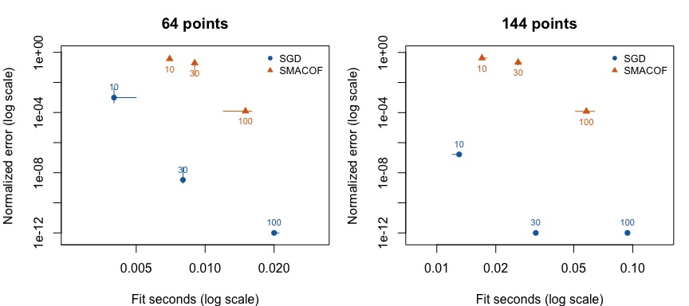

Separate schedules: median normalized error versus median fitting time; bars show the interquartile ranges over five starts. Labels are pass/iteration allowances.

### 64 points

| Method | Raw stress | Normalized error | Fit seconds | Passes/iterations | Termination |
| --- | --- | --- | --- | --- | --- |
| Generating reference | 2.082e-29 | 7.700e-17 | NA | NA | Reference only |
| Classical MDS | 1.008e-26 | 1.695e-15 | 0.001 | NA | Spectral reference |
| SGD | 1.165e-28 | 1.822e-16 | 0.021 | 100 | iteration_limit |
| SMACOF | 5.238e-05 | 1.222e-04 | 0.015 | 75 | stress_tolerance |

Fixed seed 1, allowance 100. Gray: generating reference; blue: SGD; orange: SMACOF. The table above reports the exact displayed fits. Alignment preserves scale.

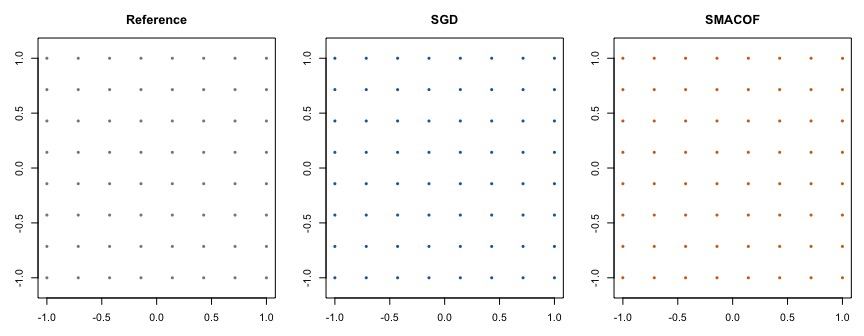

### 144 points

| Method | Raw stress | Normalized error | Fit seconds | Passes/iterations | Termination |
| --- | --- | --- | --- | --- | --- |
| Generating reference | 6.110e-29 | 6.115e-17 | NA | NA | Reference only |
| Classical MDS | 9.170e-27 | 7.492e-16 | 0.002 | NA | Spectral reference |
| SGD | 2.585e-28 | 1.258e-16 | 0.093 | 100 | iteration_limit |
| SMACOF | 2.217e-04 | 1.165e-04 | 0.036 | 53 | stress_tolerance |

Fixed seed 1, allowance 100. Gray: generating reference; blue: SGD; orange: SMACOF. The table above reports the exact displayed fits. Alignment preserves scale.

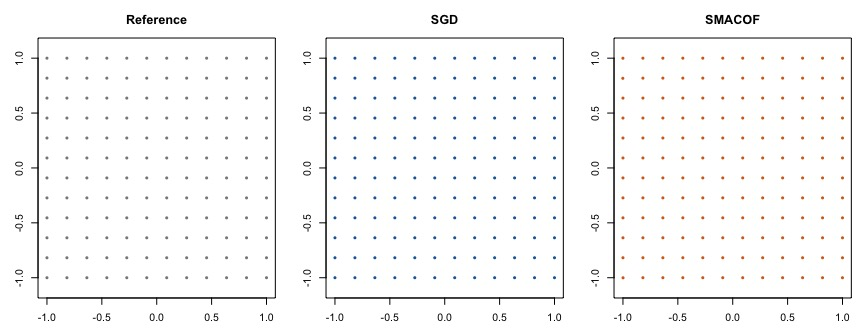

## Paraboloid: Ambient Euclidean

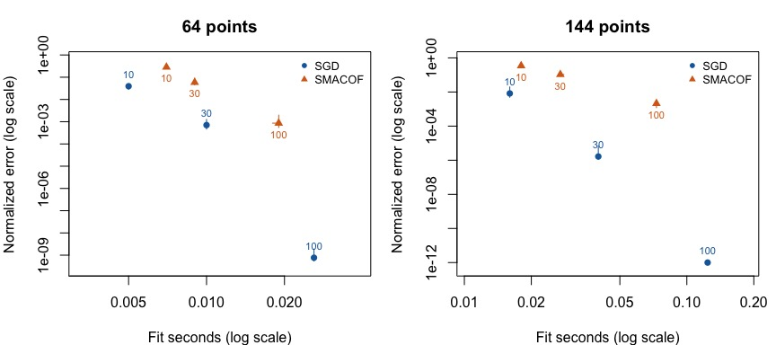

Separate schedules: median normalized error versus median fitting time; bars show the interquartile ranges over five starts. Labels are pass/iteration allowances.

### 64 points

| Method | Raw stress | Normalized error | Fit seconds | Passes/iterations | Termination |
| --- | --- | --- | --- | --- | --- |
| Generating reference | 9.285e-30 | 4.677e-17 | NA | NA | Reference only |
| Classical MDS | 3.208e-27 | 8.693e-16 | 0.000 | NA | Spectral reference |
| SGD | 2.392e-16 | 2.374e-10 | 0.026 | 100 | iteration_limit |
| SMACOF | 3.144e-03 | 8.607e-04 | 0.018 | 100 | iteration_limit |

Fixed seed 1, allowance 100. Gray: generating reference; blue: SGD; orange: SMACOF. The table above reports the exact displayed fits. Alignment preserves scale.

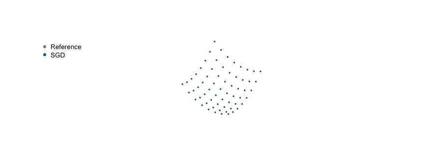

### 144 points

| Method | Raw stress | Normalized error | Fit seconds | Passes/iterations | Termination |
| --- | --- | --- | --- | --- | --- |
| Generating reference | 4.003e-29 | 4.524e-17 | NA | NA | Reference only |
| Classical MDS | 2.416e-26 | 1.111e-15 | 0.002 | NA | Spectral reference |
| SGD | 1.086e-26 | 7.450e-16 | 0.126 | 100 | iteration_limit |
| SMACOF | 6.630e-01 | 5.821e-03 | 0.074 | 100 | iteration_limit |

Fixed seed 1, allowance 100. Gray: generating reference; blue: SGD; orange: SMACOF. The table above reports the exact displayed fits. Alignment preserves scale.

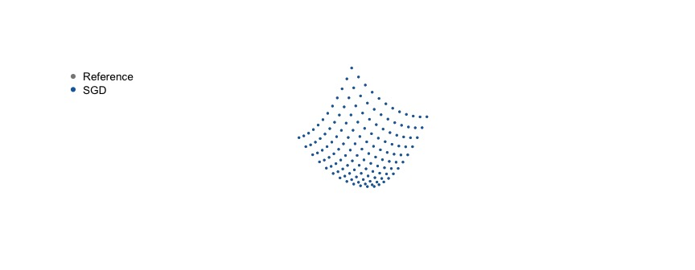

## Saddle: Ambient Euclidean

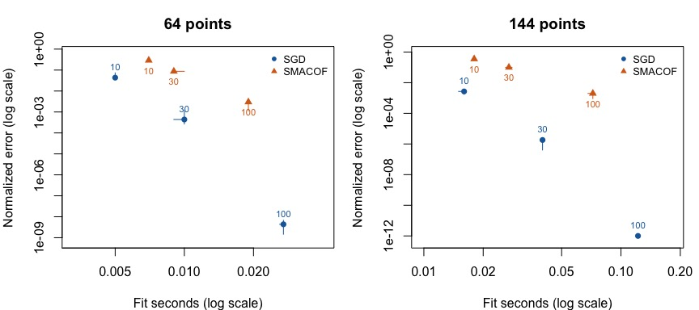

Separate schedules: median normalized error versus median fitting time; bars show the interquartile ranges over five starts. Labels are pass/iteration allowances.

### 64 points

| Method | Raw stress | Normalized error | Fit seconds | Passes/iterations | Termination |
| --- | --- | --- | --- | --- | --- |
| Generating reference | 1.749e-29 | 6.420e-17 | NA | NA | Reference only |
| Classical MDS | 2.021e-27 | 6.901e-16 | 0.001 | NA | Spectral reference |
| SGD | 9.097e-15 | 1.464e-09 | 0.027 | 100 | iteration_limit |
| SMACOF | 3.787e-02 | 2.987e-03 | 0.019 | 100 | iteration_limit |

Fixed seed 1, allowance 100. Gray: generating reference; blue: SGD; orange: SMACOF. The table above reports the exact displayed fits. Alignment preserves scale.

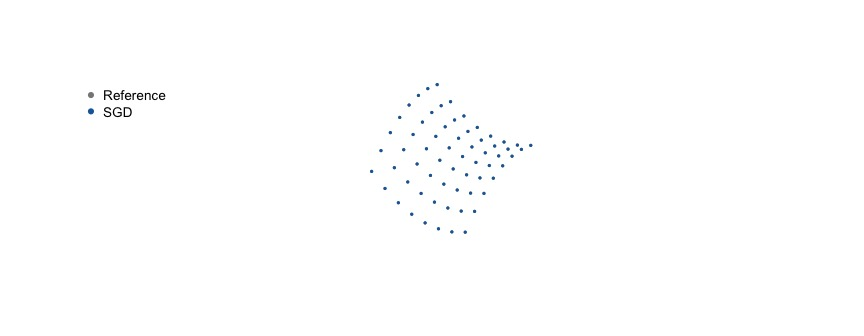

### 144 points

| Method | Raw stress | Normalized error | Fit seconds | Passes/iterations | Termination |
| --- | --- | --- | --- | --- | --- |
| Generating reference | 6.158e-29 | 5.611e-17 | NA | NA | Reference only |
| Classical MDS | 1.016e-26 | 7.207e-16 | 0.003 | NA | Spectral reference |
| SGD | 1.092e-26 | 7.472e-16 | 0.122 | 100 | iteration_limit |
| SMACOF | 1.161e-03 | 2.436e-04 | 0.074 | 95 | stress_tolerance |

Fixed seed 1, allowance 100. Gray: generating reference; blue: SGD; orange: SMACOF. The table above reports the exact displayed fits. Alignment preserves scale.

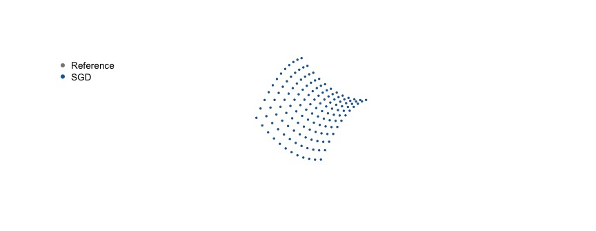

## Paraboloid: Local graph paths

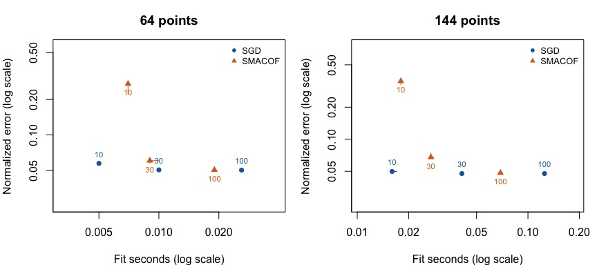

Separate schedules: median normalized error versus median fitting time; bars show the interquartile ranges over five starts. Labels are pass/iteration allowances.

### 64 points

| Method | Raw stress | Normalized error | Fit seconds | Passes/iterations | Termination |
| --- | --- | --- | --- | --- | --- |
| Generating reference | 1.773e+02 | 1.732e-01 | NA | NA | Reference only |
| Classical MDS | 1.650e+01 | 5.283e-02 | 0.001 | NA | Spectral reference |
| SGD | 1.491e+01 | 5.023e-02 | 0.026 | 100 | iteration_limit |
| SMACOF | 1.506e+01 | 5.049e-02 | 0.019 | 100 | iteration_limit |

Fixed seed 1, allowance 100. Gray: generating reference; blue: SGD; orange: SMACOF. The table above reports the exact displayed fits. Alignment preserves scale.

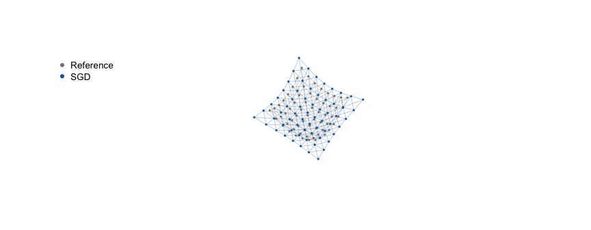

### 144 points

| Method | Raw stress | Normalized error | Fit seconds | Passes/iterations | Termination |
| --- | --- | --- | --- | --- | --- |
| Generating reference | 7.825e+02 | 1.698e-01 | NA | NA | Reference only |
| Classical MDS | 6.948e+01 | 5.059e-02 | 0.006 | NA | Spectral reference |
| SGD | 6.152e+01 | 4.761e-02 | 0.125 | 100 | iteration_limit |
| SMACOF | 7.396e+01 | 5.220e-02 | 0.072 | 100 | iteration_limit |

Fixed seed 1, allowance 100. Gray: generating reference; blue: SGD; orange: SMACOF. The table above reports the exact displayed fits. Alignment preserves scale.

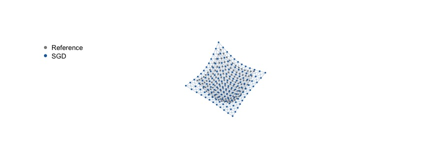

## Saddle: Local graph paths

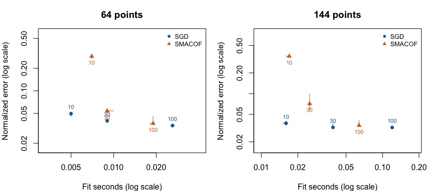

Separate schedules: median normalized error versus median fitting time; bars show the interquartile ranges over five starts. Labels are pass/iteration allowances.

### 64 points

| Method | Raw stress | Normalized error | Fit seconds | Passes/iterations | Termination |
| --- | --- | --- | --- | --- | --- |
| Generating reference | 7.164e+01 | 1.175e-01 | NA | NA | Reference only |
| Classical MDS | 9.073e+00 | 4.183e-02 | 0.001 | NA | Spectral reference |
| SGD | 6.154e+00 | 3.445e-02 | 0.027 | 100 | iteration_limit |
| SMACOF | 1.105e+01 | 4.615e-02 | 0.019 | 100 | iteration_limit |

Fixed seed 1, allowance 100. Gray: generating reference; blue: SGD; orange: SMACOF. The table above reports the exact displayed fits. Alignment preserves scale.

#### Surface-shape alignment

The gray reference stays fixed. The blue and orange layouts are moved to match surface shape rather than vertex labels. Choose SGD, SMACOF, or both.

| Backend | Subdivisions per edge | Surface RMS before | Surface RMS after |
| --- | --- | --- | --- |
| SGD | 6 | 0.3528 | 0.1588 |
| SGD | 9 | 0.3524 | 0.1579 |
| SMACOF | 6 | 0.2916 | 0.2378 |
| SMACOF | 9 | 0.2911 | 0.2369 |

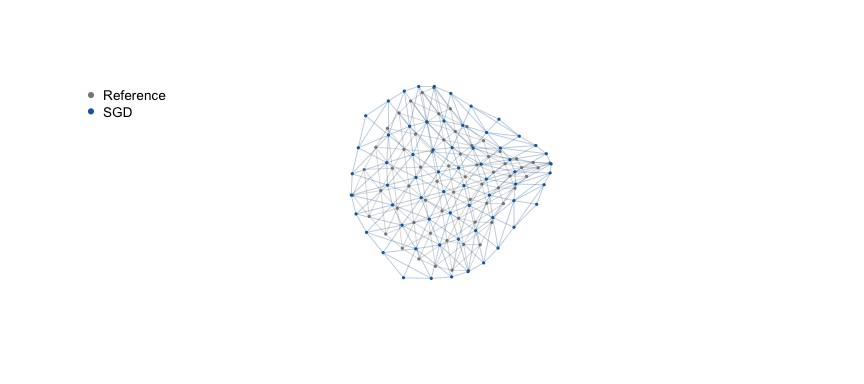

### 144 points

| Method | Raw stress | Normalized error | Fit seconds | Passes/iterations | Termination |
| --- | --- | --- | --- | --- | --- |
| Generating reference | 3.116e+02 | 1.143e-01 | NA | NA | Reference only |
| Classical MDS | 3.776e+01 | 3.979e-02 | 0.005 | NA | Spectral reference |
| SGD | 2.491e+01 | 3.232e-02 | 0.120 | 100 | iteration_limit |
| SMACOF | 3.993e+01 | 4.092e-02 | 0.063 | 100 | iteration_limit |

Fixed seed 1, allowance 100. Gray: generating reference; blue: SGD; orange: SMACOF. The table above reports the exact displayed fits. Alignment preserves scale.

#### Surface-shape alignment

The gray reference stays fixed. The blue and orange layouts are moved to match surface shape rather than vertex labels. Choose SGD, SMACOF, or both.

| Backend | Subdivisions per edge | Surface RMS before | Surface RMS after |
| --- | --- | --- | --- |
| SGD | 6 | 0.3708 | 0.1511 |
| SGD | 9 | 0.3706 | 0.1506 |
| SMACOF | 6 | 0.1742 | 0.1737 |
| SMACOF | 9 | 0.1738 | 0.1734 |

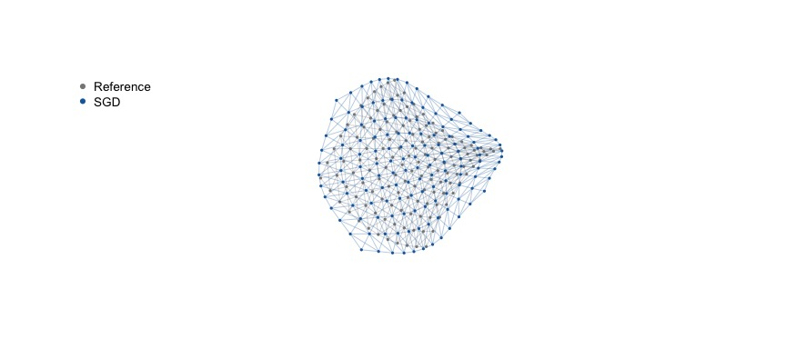

## Spatial helix graph: Local graph paths

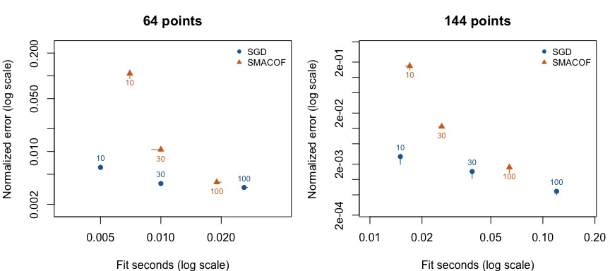

Separate schedules: median normalized error versus median fitting time; bars show the interquartile ranges over five starts. Labels are pass/iteration allowances.

### 64 points

| Method | Raw stress | Normalized error | Fit seconds | Passes/iterations | Termination |
| --- | --- | --- | --- | --- | --- |
| Generating reference | 1.084e+04 | 5.825e-01 | NA | NA | Reference only |
| Classical MDS | 3.686e+00 | 1.074e-02 | 0.001 | NA | Spectral reference |
| SGD | 3.605e-01 | 3.359e-03 | 0.027 | 100 | iteration_limit |
| SMACOF | 4.930e-01 | 3.929e-03 | 0.020 | 100 | iteration_limit |

Fixed seed 1, allowance 100. Gray: generating reference; blue: SGD; orange: SMACOF. The table above reports the exact displayed fits. Alignment preserves scale.

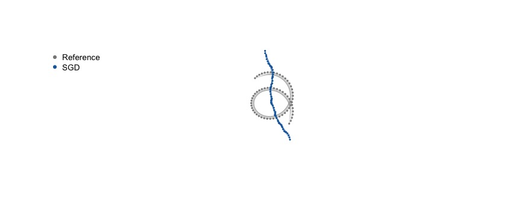

### 144 points

| Method | Raw stress | Normalized error | Fit seconds | Passes/iterations | Termination |
| --- | --- | --- | --- | --- | --- |
| Generating reference | 5.935e+04 | 5.930e-01 | NA | NA | Reference only |
| Classical MDS | 4.922e-01 | 1.708e-03 | 0.003 | NA | Spectral reference |
| SGD | 6.197e-02 | 6.059e-04 | 0.119 | 100 | iteration_limit |
| SMACOF | 9.666e-01 | 2.393e-03 | 0.063 | 100 | iteration_limit |

Fixed seed 1, allowance 100. Gray: generating reference; blue: SGD; orange: SMACOF. The table above reports the exact displayed fits. Alignment preserves scale.

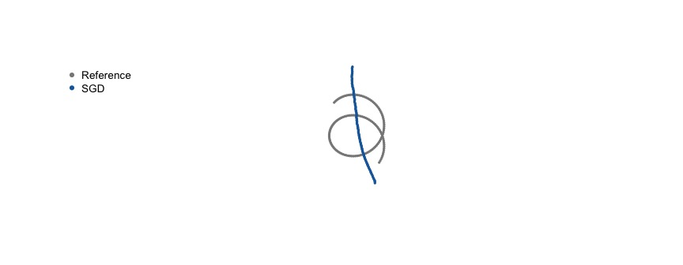

Surface alignment uses symmetric iterative closest-point matching on the triangulated surfaces. Each triangle is sampled at the centers of nine equal-area subtriangles; samples are weighted by triangle area. The search starts from the vertex-aligned fit at 24 rotations about the reference’s vertical axis, with and without a vertical reflection. Each of the 48 starts allows 80 updates, stopping when the change in mean squared surface distance is at most one billionth of its initial value. Updates can rotate about any axis. The lowest sampled error is selected, retaining the initial alignment if none improves it. This is a local search, not a guarantee of the globally best surface match.

The tables evaluate the result on denser samples: 36 and 81 subtriangles per triangle. **Surface RMS** is the square root of the mean squared nearest-sample distance, averaged in both directions and weighted by surface area. It is in coordinate units; smaller values indicate closer surfaces. It is an approximation to surface distance, not vertex error or MDS stress. The mesh, its boundary and the underlying fitted coordinates are unchanged.

## The effect of stress weighting

Uniform stress measures squared errors in distance units. The paper’s weighting instead minimizes squared **relative** errors:

$$S_{\mathrm{relative}}(Z)
= \sum_{i<j}\frac{(\lVert z_i-z_j\rVert-d_{ij})^2}{d_{ij}^2}.$$

For example, an error of 0.2 on a target distance of 1 counts as much as an error of 2 on a target distance of 10. Thus shorter distances receive more influence than under uniform weighting. This changes the objective for both optimizers; it is separate from the edge lengths used to compute graph shortest paths.

Select the same weighting for either backend:

```r
g <- suitesparse.graph('dwt_307')
prepared <- prepare.graph.geodesic.mds(edges=g$edges,n=g$n,edge.weights=g$edge_weights)
start <- withr::with_seed(1,matrix(rnorm(g$n*3),g$n,3))
sgd <- metric.mds(prepared = prepared, dim = 3, init = start,
                 backend = "sgd", pair.weights = "inverse_squared",
                 max.iter = 100, diagnostics = FALSE)
smacof <- metric.mds(prepared = prepared, dim = 3, init = start,
                    backend = "smacof", pair.weights = "inverse_squared",
                    max.iter = 100, eps = 1e-8, diagnostics = FALSE)
```

Set `pair.weights = "uniform"` to use the original objective. Inverse-squared weighting requires positive distances between distinct vertices; zero distances are rejected rather than replaced by a small constant. The learning-rate schedule stays the same as above, in RMS-normalized distance units. These fits use the paper’s weighting, with grip’s documented schedule and initialization.

This **separate 60-fit experiment** compares the saddle, paraboloid, and spatial helix graphs with 64 vertices each. Each backend and weighting receives the same five random starting shapes, seeds 1–5, with one start per fit and an allowance of 100 passes or iterations. The wrapper fits the initial and final coordinate scale to the selected objective. The allowance, SGD controls, and SMACOF tolerance match the original comparison. Each worker has 30 seconds; the whole experiment has 600 seconds. Failed fits remain in the results.

Every returned layout is scored under **both** definitions: uniform normalized error and root-mean-square relative error. Compare rows within the same error column. The two columns measure different goals; their magnitudes do not select a universally better weighting. Reported scores use the returned coordinates without fitting another scale for the other objective.

The run returned coordinates for **60 of 60 fits**. As above, a returned fit does not imply convergence. Tables give medians across all five starts and then the scores of the exact displayed runs. The figures use the preselected seed 1. All four layouts and the gray generating reference share the same camera and scale; the saddle uses the surface-shape alignment described above for all four backend/weighting combinations. The other examples use vertex-based Procrustes alignment. Neither alignment resizes or deforms the layouts.

In this run, inverse-squared weighting lowered median relative error in **6 of 6 graph–backend comparisons**, while increasing median uniform error in **6**. The figures show how that change in priorities alters each layout.

### Saddle: uniform versus inverse-squared weights

Medians across five starting shapes:

| Backend | Weighting | Returned | Attempted | Uniform error | Relative error | Fit seconds |
| --- | --- | --- | --- | --- | --- | --- |
| SGD | Uniform | 5 | 5 | 0.0344 | 0.0435 | 0.027 |
| SMACOF | Uniform | 5 | 5 | 0.0367 | 0.0458 | 0.018 |
| SMACOF | Inverse-squared | 5 | 5 | 0.0422 | 0.0442 | 0.019 |
| SGD | Inverse-squared | 5 | 5 | 0.0383 | 0.0401 | 0.027 |

Displayed runs (seed 1):

| Backend | Weighting | Uniform error | Relative error | Fit seconds | Termination | Status |
| --- | --- | --- | --- | --- | --- | --- |
| SGD | Uniform | 0.0344 | 0.0435 | 0.027 | iteration_limit | ok |
| SGD | Inverse-squared | 0.0382 | 0.0401 | 0.027 | iteration_limit | ok |
| SMACOF | Uniform | 0.0462 | 0.0536 | 0.018 | iteration_limit | ok |
| SMACOF | Inverse-squared | 0.0385 | 0.0403 | 0.018 | iteration_limit | ok |

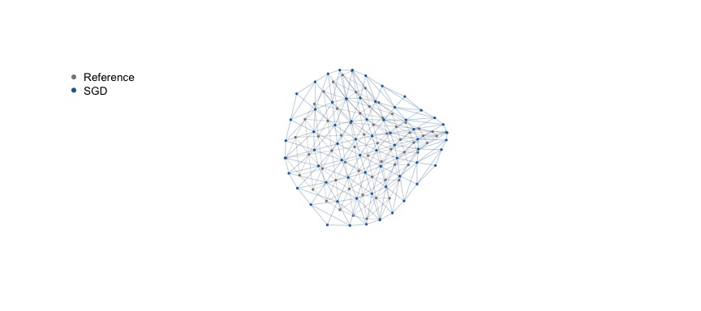

### Paraboloid: uniform versus inverse-squared weights

Medians across five starting shapes:

| Backend | Weighting | Returned | Attempted | Uniform error | Relative error | Fit seconds |
| --- | --- | --- | --- | --- | --- | --- |
| SGD | Uniform | 5 | 5 | 0.0502 | 0.0623 | 0.027 |
| SMACOF | Uniform | 5 | 5 | 0.0505 | 0.0625 | 0.019 |
| SMACOF | Inverse-squared | 5 | 5 | 0.0605 | 0.0529 | 0.019 |
| SGD | Inverse-squared | 5 | 5 | 0.0608 | 0.0529 | 0.027 |

Displayed runs (seed 1):

| Backend | Weighting | Uniform error | Relative error | Fit seconds | Termination | Status |
| --- | --- | --- | --- | --- | --- | --- |
| SGD | Uniform | 0.0502 | 0.0623 | 0.027 | iteration_limit | ok |
| SGD | Inverse-squared | 0.0608 | 0.0529 | 0.027 | iteration_limit | ok |
| SMACOF | Uniform | 0.0505 | 0.0625 | 0.020 | iteration_limit | ok |
| SMACOF | Inverse-squared | 0.0605 | 0.0529 | 0.020 | iteration_limit | ok |

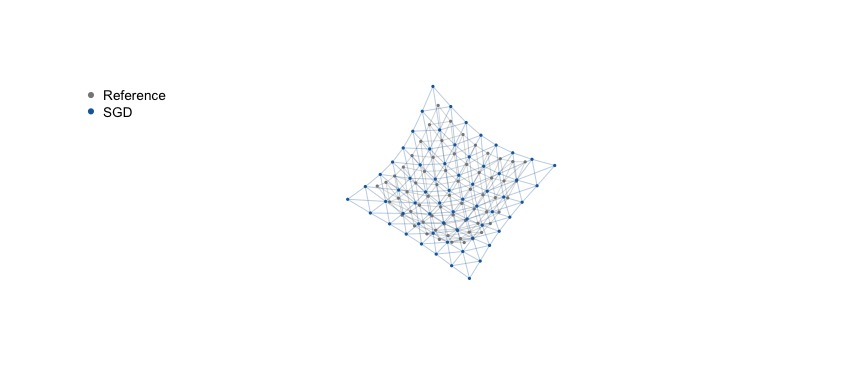

### Spatial helix graph: uniform versus inverse-squared weights

Medians across five starting shapes:

| Backend | Weighting | Returned | Attempted | Uniform error | Relative error | Fit seconds |
| --- | --- | --- | --- | --- | --- | --- |
| SGD | Uniform | 5 | 5 | 0.0033 | 0.0104 | 0.027 |
| SMACOF | Uniform | 5 | 5 | 0.0039 | 0.0155 | 0.019 |
| SMACOF | Inverse-squared | 5 | 5 | 0.0154 | 0.0125 | 0.019 |
| SGD | Inverse-squared | 5 | 5 | 0.0050 | 0.0085 | 0.027 |

Displayed runs (seed 1):

| Backend | Weighting | Uniform error | Relative error | Fit seconds | Termination | Status |
| --- | --- | --- | --- | --- | --- | --- |
| SGD | Uniform | 0.0034 | 0.0104 | 0.027 | iteration_limit | ok |
| SGD | Inverse-squared | 0.0051 | 0.0082 | 0.027 | iteration_limit | ok |
| SMACOF | Uniform | 0.0039 | 0.0171 | 0.019 | iteration_limit | ok |
| SMACOF | Inverse-squared | 0.0161 | 0.0126 | 0.019 | iteration_limit | ok |

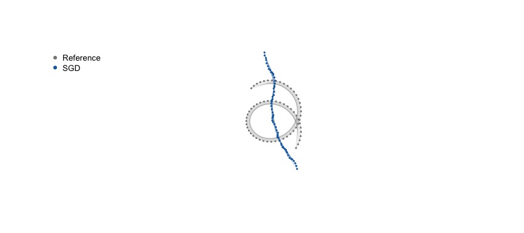

## Sparse SGD for larger graphs

`metric.mds(approximation = "sparse")` uses representative vertices (pivots) to approximate long-range interactions while retaining graph edges. It implements the sparse SGD method of [Zheng et al. (2018)](https://doi.org/10.1109/TVCG.2018.2859997), based on [Ortmann et al. (2017)](https://doi.org/10.7155/jgaa.00440), with inverse-squared weighting and no all-pairs distance preparation.

See Sparse SGD for larger graphs for usage and a separate comparison of full SGD, sparse SGD with several pivot counts, and weighted GRIP. It includes 3D views, repeated runs, total layout times, measured peak memory, and an independently scored 4,096-vertex saddle.

## Reproduce the experiment

Building this vignette displays saved experiment results. To repeat all 420 fits, install the R packages **callr** and **smacof**, then run these commands in the grip source folder:

```bash
mkdir -p ../comparison-library
R CMD INSTALL --preclean --library=../comparison-library . > ../comparison-install.log 2>&1
Rscript tools/pkg/build-metric-mds-comparison.R ../fresh-results ../comparison-library ../comparison-install.log
```

To repeat the separate weighting comparison, add `weighting` as the final argument and choose another results folder:

```bash
Rscript tools/pkg/build-metric-mds-comparison.R ../fresh-weighting-results ../comparison-library ../comparison-install.log weighting
```

The script saves the timings, fitted coordinates, and any errors in `fresh-results`, beside the grip source folder. Choose a new results folder for each run. Instructions for recreating the figures are in the [reproduction guide](https://github.com/pgajer/grip/blob/main/tools/README.md#metric-mds-comparison-vignette).

## References

- Zheng, J. X., Pawar, S. and Goodman, D. F. (2018). *Graph Drawing by Stochastic Gradient Descent*. [doi:10.1109/TVCG.2018.2859997](https://doi.org/10.1109/TVCG.2018.2859997).
- Hangan, D., Kobourov, S. and Miller, J. (2026). *Bridging Graph Drawing and Dimensionality Reduction with Stochastic Stress Optimization*. [arXiv:2605.00641](https://arxiv.org/abs/2605.00641).
- Mair, P., Groenen, P. J. F. and de Leeuw, J. (2022). *More on Multidimensional Scaling and Unfolding in R: smacof Version 2*. Journal of Statistical Software, 102(10). [doi:10.18637/jss.v102.i10](https://doi.org/10.18637/jss.v102.i10).